# Using a discrete observation model in lgpr

Juho Timonen

2025-10-30

```r
require("lgpr")
# Loading required package: lgpr
# Attached lgpr 1.2.5, using rstan 2.32.7. Type ?lgpr to get started.
require("ggplot2")
# Loading required package: ggplot2
require("rstan")
# Loading required package: rstan
# Loading required package: StanHeaders
#
# rstan version 2.32.7 (Stan version 2.32.2)
# For execution on a local, multicore CPU with excess RAM we recommend calling
# options(mc.cores = parallel::detectCores()).
# To avoid recompilation of unchanged Stan programs, we recommend calling
# rstan_options(auto_write = TRUE)
# For within-chain threading using `reduce_sum()` or `map_rect()` Stan functions,
# change `threads_per_chain` option:
# rstan_options(threads_per_chain = 1)
```

# 1 Introduction

In this tutorial we simulate and analyse count data.

## 1.1 Binomial data

We first show how to generate binomial data

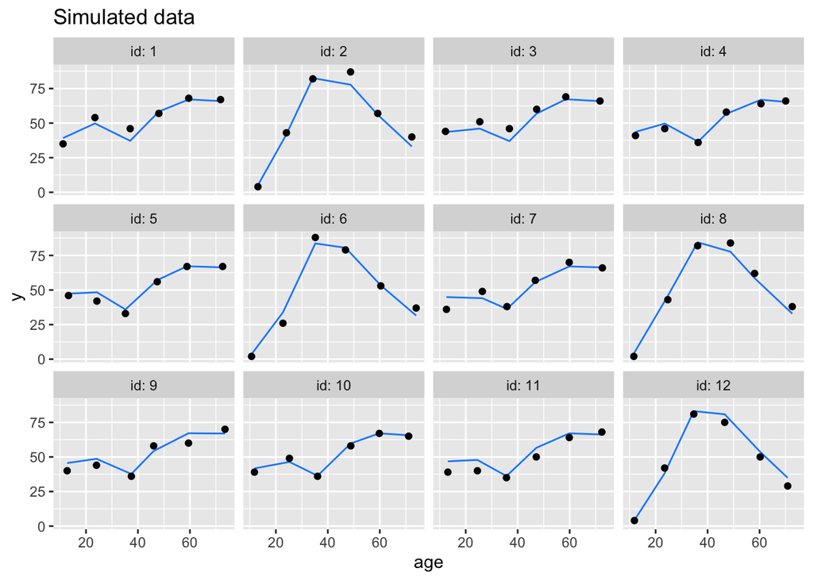

```r
set.seed(131)
simData <- simulate_data(
  N = 12,
  t_data = seq(12, 72, by = 12),
  covariates = c(2),
  noise_type = "binomial",
  relevances = c(0, 1, 1),
  lengthscales = c(18, 24, 18),
  N_trials = 100,
  t_jitter = 1
)

plot_sim(simData)
# Warning: `aes_string()` was deprecated in ggplot2 3.0.0.
# ℹ Please use tidy evaluation idioms with `aes()`.
# ℹ See also `vignette("ggplot2-in-packages")` for more information.
# ℹ The deprecated feature was likely used in the lgpr package.
#   Please report the issue at <https://github.com/jtimonen/lgpr/issues>.
# This warning is displayed once every 8 hours.
# Call `lifecycle::last_lifecycle_warnings()` to see where this warning was generated.
# - Dots are noisy observations of the response var.
# - Line is the true signal mapped through inv. link fun.
#   (and multiplied by number of trials)
```

## 1.2 Beta-binomial data

The noise level in the previous example was rather low. To generate more noisy observations, we can draw from the beta-binomial distribution. The overdispersion parameter $\gamma \in (0,1)$ controls the noise level, so that $\gamma \rightarrow 0$ would be equivalent to binomial noise (no overdispersion) and larger values mean more noise. Here we set `gamma = 0.3`.

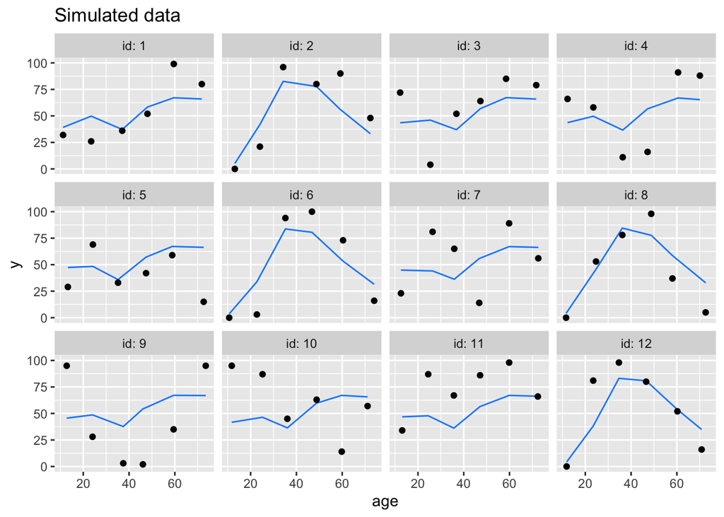

```r
set.seed(131)
simData <- simulate_data(
  N = 12,
  t_data = seq(12, 72, by = 12),
  covariates = c(2),
  noise_type = "bb",
  gamma = 0.3,
  relevances = c(0, 1, 1),
  lengthscales = c(18, 24, 18),
  N_trials = 100,
  t_jitter = 1
)

plot_sim(simData)
# - Dots are noisy observations of the response var.
# - Line is the true signal mapped through inv. link fun.
#   (and multiplied by number of trials)
```

```r
dat <- simData@data
str(dat)
# 'data.frame': 72 obs. of  4 variables:
#  $ id : Factor w/ 12 levels "1","2","3","4",..: 1 1 1 1 1 1 2 2 2 2 ...
#  $ age: num  11.2 23.5 37 48 59.5 ...
#  $ z  : Factor w/ 2 levels "1","2": 2 2 2 2 2 2 1 1 1 1 ...
#  $ y  : int  32 26 36 52 99 80 0 21 96 80 ...
```

## 1.3 Defining model

To use beta-binomial observation model in our analysis, we use the `likelihood` argument of `lgp()`. Here we define a $\text{Beta}(2,2)$ prior for the `gamma` parameter.

```r
my_prior <- list(
  alpha = student_t(20),
  gamma = bet(2, 2)
)
```

# 2 Fitting the model

We fit a model using the generated beta-binomial data.

```r
fit <- lgp(y ~ age + age | id + age | z,
  data = dat,
  likelihood = "bb",
  num_trials = 100,
  prior = my_prior,
  refresh = 300,
  chains = 3,
  cores = 3,
  control = list(adapt_delta = 0.95),
  iter = 3000
)
```

```r
print(fit)
# An object of class lgpfit. See ?lgpfit for more info.
# Inference for Stan model: lgp_latent.
# 3 chains, each with iter=3000; warmup=1500; thin=1;
# post-warmup draws per chain=1500, total post-warmup draws=4500.
#
#          mean se_mean   sd 2.5%  25%  50%  75% 97.5% n_eff Rhat
# alpha[1] 1.11    0.01 0.49 0.44 0.75 1.01 1.37  2.31  2026    1
# alpha[2] 0.37    0.01 0.28 0.01 0.15 0.31 0.53  1.04   530    1
# alpha[3] 1.30    0.01 0.47 0.63 0.97 1.22 1.55  2.40  1868    1
# ell[1]   0.85    0.01 0.46 0.21 0.51 0.75 1.12  1.88  1119    1
# ell[2]   1.10    0.03 1.49 0.13 0.44 0.69 1.18  4.54  2023    1
# ell[3]   0.74    0.01 0.28 0.26 0.55 0.73 0.91  1.34  1326    1
# gamma[1] 0.27    0.00 0.05 0.14 0.24 0.27 0.30  0.36   631    1
#
# Samples were drawn using NUTS(diag_e) at Thu Oct 30 23:09:01 2025.
# For each parameter, n_eff is a crude measure of effective sample size,
# and Rhat is the potential scale reduction factor on split chains (at
# convergence, Rhat=1).
```

We see that the posterior mean of the `gamma` parameter is close to the value used in simulation (0.3). We visualize its posterior draws for each MCMC chain:

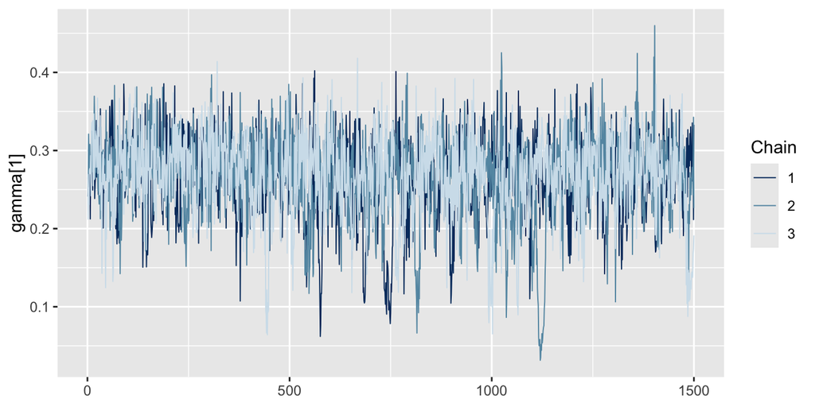

```r
plot_draws(fit, type = "trace", regex_pars = "gamma")
```

```r
relevances(fit)
#        gp(age) gp(age)*zs(id)  gp(age)*zs(z)          noise
#     0.14125061     0.04760887     0.25839685     0.55274366
```

# 3 Visualising inferred signal and its components

We subsample 50 draws from the posterior of each component $f^{(j)}$, $j=1,2,3$

```r
draws <- sample.int(1000, 50)
```

and visualize them

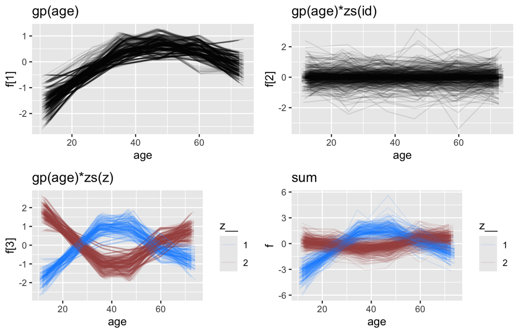

```r
p <- pred(fit, draws = draws)
plot_components(fit, pred = p, alpha = 0.1, color_by = c(NA, NA, "z", "z"))
```

as well as the sum $f = f^{(1)} + f^{(2)} + f^{(3)}$

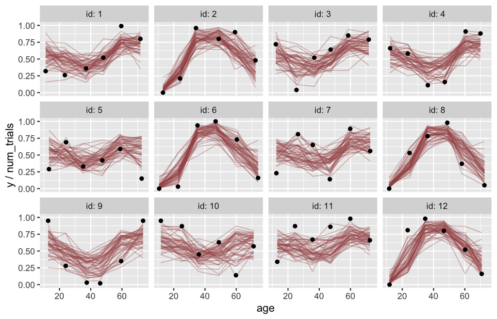

```r
plot_pred(fit, pred = p, alpha = 0.3)
```

# 4 Out-of-sample prediction

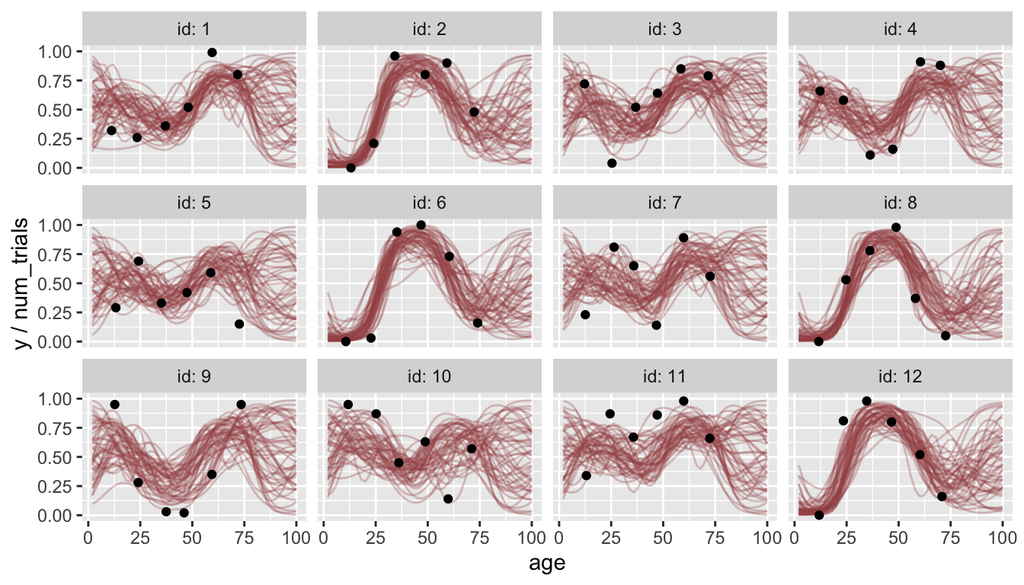

```r
t <- seq(2, 100, by = 2)
x_pred <- new_x(dat, t)
p <- pred(fit, x_pred, draws = draws)
# Extrapolating function posterior draws...
# |   10%|   20%|   30%|   40%|   50%|   60%|   70%|   80%|   90%|  100%|
# ======================================================================
# c_hat_pred not given, using constant c_hat_pred = 0.14581335876668
# Done.
plot_pred(fit, p, alpha = 0.3)
```

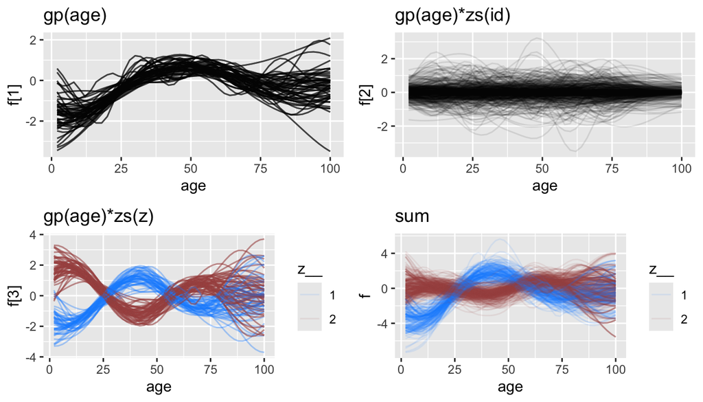

```r
plot_components(fit, pred = p, alpha = 0.1, color_by = c(NA, NA, "z", "z"))
```

# 5 Computing environment

```r
sessionInfo()
# R version 4.4.1 (2024-06-14)
# Platform: aarch64-apple-darwin20
# Running under: macOS Sonoma 14.6.1
#
# Matrix products: default
# BLAS:   /Library/Frameworks/R.framework/Versions/4.4-arm64/Resources/lib/libRblas.0.dylib
# LAPACK: /Library/Frameworks/R.framework/Versions/4.4-arm64/Resources/lib/libRlapack.dylib;  LAPACK version 3.12.0
#
# locale:
# [1] C/UTF-8/C/C/C/C
#
# time zone: Europe/Helsinki
# tzcode source: internal
#
# attached base packages:
# [1] stats     graphics  grDevices utils     datasets  methods   base
#
# other attached packages:
# [1] rstan_2.32.7        StanHeaders_2.32.10 ggplot2_4.0.0
# [4] lgpr_1.2.5          rmarkdown_2.30
#
# loaded via a namespace (and not attached):
#  [1] tensorA_0.36.2.1      sass_0.4.10           generics_0.1.4
#  [4] stringi_1.8.7         digest_0.6.37         magrittr_2.0.4
#  [7] evaluate_1.0.5        grid_4.4.1            RColorBrewer_1.1-3
# [10] fastmap_1.2.0         plyr_1.8.9            jsonlite_2.0.0
# [13] pkgbuild_1.4.8        backports_1.5.0       gridExtra_2.3
# [16] QuickJSR_1.8.1        scales_1.4.0          codetools_0.2-20
# [19] jquerylib_0.1.4       abind_1.4-8           cli_3.6.5
# [22] crayon_1.5.3          rlang_1.1.6           withr_3.0.2
# [25] cachem_1.1.0          yaml_2.3.10           tools_4.4.1
# [28] inline_0.3.21         parallel_4.4.1        reshape2_1.4.4
# [31] checkmate_2.3.3       rstantools_2.5.0      dplyr_1.1.4
# [34] colorspace_2.1-2      curl_6.2.3            posterior_1.6.1
# [37] vctrs_0.6.5           R6_2.6.1              matrixStats_1.5.0
# [40] stats4_4.4.1          lifecycle_1.0.4       stringr_1.5.2
# [43] V8_6.0.0              MASS_7.3-60.2         pkgconfig_2.0.3
# [46] RcppParallel_5.1.11-1 pillar_1.11.1         bslib_0.9.0
# [49] gtable_0.3.6          loo_2.8.0             glue_1.8.0
# [52] Rcpp_1.1.0            xfun_0.53             tibble_3.3.0
# [55] tidyselect_1.2.1      knitr_1.50            farver_2.1.2
# [58] bayesplot_1.14.0      htmltools_0.5.8.1     labeling_0.4.3
# [61] compiler_4.4.1        S7_0.2.0              distributional_0.5.0
```